# Homerange Overlap Exercise

In this exercise, you will compute the overlap betweeh the ‘core’ and ‘home range’ areas of three buffalo in Kruger national park. The ecological questions driving this exercise center around theories we want to explore about why buffalo home ranges sometimes overlap and sometimes not. Is it due to availablity of resources (which are highly seasonal)? Could it be due reproductive strategies or herd dynamics?

To answer these questions, we have to first measure when, where, and by how much home ranges overlap. We will use data for three individual buffalo from Kruger National Park in South Africa[^1]: cilla, gabs, & mvubu (cgm). These data were downloaded from MoveBank.org. To help you get started, someone has already imported the trajectories for these three individuals into R, and turned them into a locoh-xy object. You can download them from the internet as follows:

```r
mycon <- url("http://tlocoh.r-forge.r-project.org/cilla-mvubu-gabs.n9770.2005-07-14.2005-10-07.lxy.01.RData")
load(mycon); close(mycon)
summary(cgm.lxy)
```

```
## Summary of LoCoH-xy object: cgm.lxy
## ***Locations
##       id num.pts dups
##    cilla    3528    6
##    mvubu    2572    3
##     gabs    3670   12
## ***Time span
##       id      begin        end     period
##    cilla 2005-07-14 2005-12-08 146.7 days
##    mvubu 2005-07-15 2005-10-29 106.6 days
##     gabs 2005-04-05 2005-10-08 185.9 days
## ***Spatial extent
##    cilla
##      x: 379415.9 - 397937.2
##      y: 7216512.5 - 7245581.4
##    mvubu
##      x: 380134.3 - 397874.1
##      y: 7216464.7 - 7244154.7
##    gabs
##      x: 379993.3 - 395533.7
##      y: 7216529 - 7240056.1
##   proj: +proj=utm +south +zone=36 +ellps=WGS84
## ***Movement properties
##       id time.step.median d.bar   vmax
##    cilla       3600 (1hs) 148.8 3.7184
##    mvubu       3600 (1hs) 127.4 0.8892
##     gabs       3600 (1hs) 109.4 0.8552
## ***Ancilliary Variables:
##    -none-
## ***Nearest-neighbor set(s):
##    none saved
```

Let’s see how much they overlap.

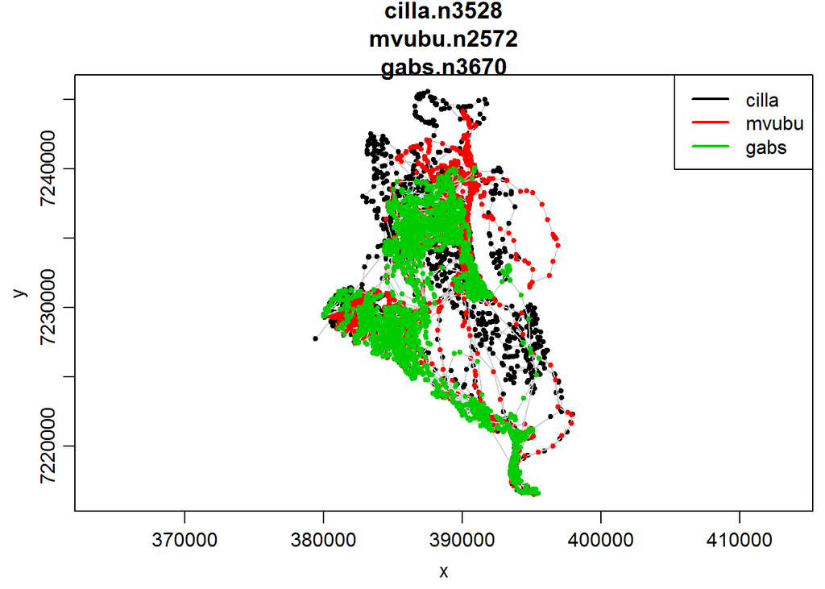

```r
plot(cgm.lxy, overlay=T, legend="topright")
```

Here are some things to think about as you proceed:

1. Record your work in a script, so you can save it and rerun the steps another time. Use comments to help you remember what you’re doing.
2. The `summary` function above shows the locations for these three individuals start / stop at different times. If this is important, you can use `lxy.thin.byfreq` to truncate the data to a set of common start / end dates
3. You’ll need to make decisions about which value of ‘s’ to use, whether to use the ‘k’ or ‘a’ method, and whether to use the same parameter values for all individuals, or tailor them for each individual.
4. T-LoCoH doesn’t have ready-made functions to compute the area of intersection of isopleths. But fortunately, isopleths are saved as SpatialPolygonDataFrames, and there are many packages that have functions to take intersections. There’s an example of computing areas of intersection at http://tlocoh.r-forge.r-project.org/tips/isopleth_overlap.html.  
   HINT: take a look at the `gIntersection` function in the rgeos package.
5. For each pair of individuals, compute the following index of association:

I = AB / (A + B - AB)

Where A and B are the area of the home range of individual A and B respectively, and AB is the area of intersection.

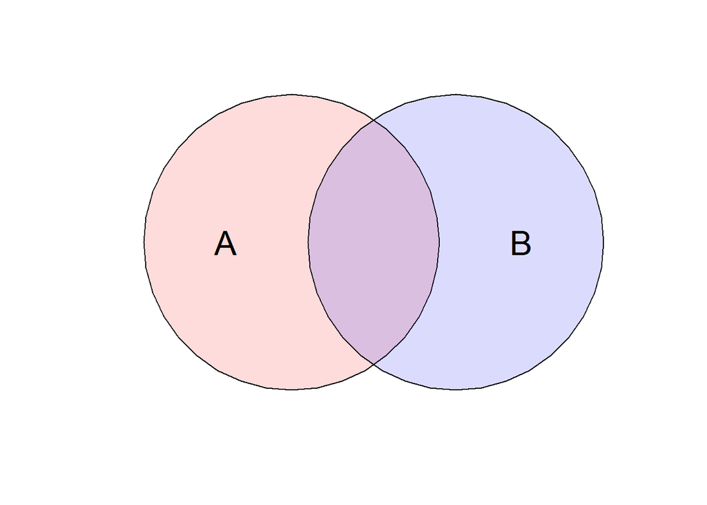

According to this index, which individuals have the greatest amount of HR overlap? What if you had measured the amount of core overlap?

[^1]: Kruger African Buffalo, GPS tracking, South Africa. PI Paul Cross. Collection of Kruger Park Buffalo data funded by NSF Grant DEB-0090323 to Wayne M. Getz. http://www.movebank.org